# demo

## 数据载入和处理

```python
import os
import sys
import warnings
sys.path.append('..')
warnings.filterwarnings('ignore')

from src.process import DataProcess
from src.text import TextTool
from src.model import XgbModel, Eval
```

```python
data_path = '../data/选题二训练集：热点事件的发展趋势预测/数据集序号和事件对应表.xlsx'
data_dir = '../data/选题二训练集：热点事件的发展趋势预测/数据/'
process = DataProcess(data_path, data_dir)
```

```python
# direct
# process.cal_numerical_feature()

# cache
import pandas as pd
process.df = pd.read_csv('../data/cache/data.csv')
```

## 文本分析

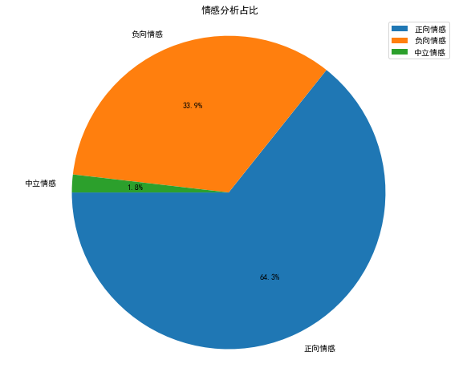

```python
process.plot_sentiment()
```

```
Building prefix dict from the default dictionary ...
Loading model from cache C:\Users\STUDYH~1\AppData\Local\Temp\jieba.cache
Loading model cost 0.565 seconds.
Prefix dict has been built succesfully.
```

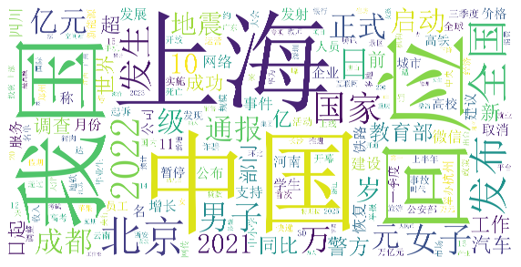

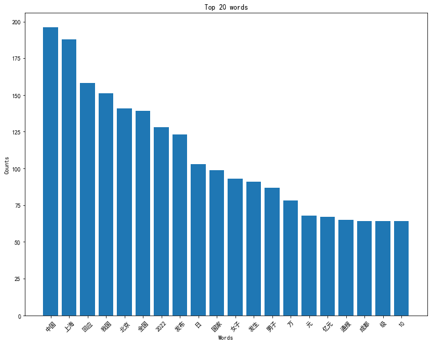

```python
tt = TextTool(process.df['事件'].tolist(), stopwords='../data/cache/stopwords.txt', overwrite=True)
tt.get_tokens()
tt.plot_wordcloud()
tt.plot_top_n_words()
```

### 正向情感

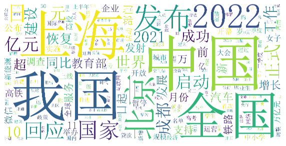

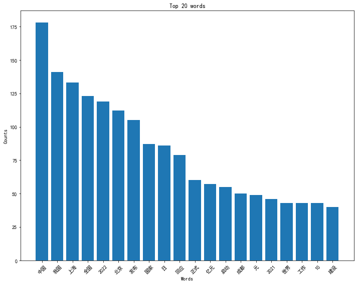

```python
pos_df = process.get_sentiment_data('正向情感')
tt.set_texts(pos_df['事件'].tolist())
tt.get_tokens()
tt.plot_wordcloud()
tt.plot_top_n_words()
```

### 中立情感

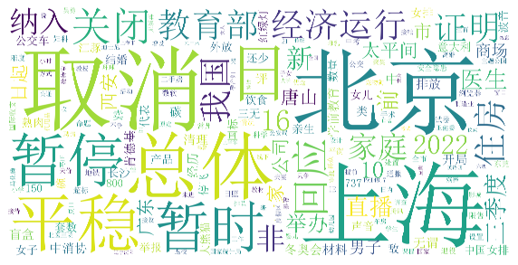

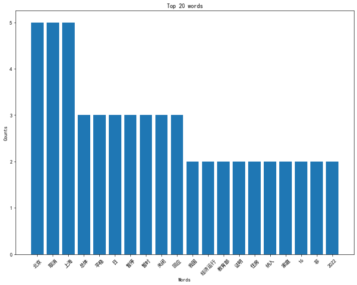

```python
pos_df = process.get_sentiment_data('中立情感')
tt.set_texts(pos_df['事件'].tolist())
tt.get_tokens()
tt.plot_wordcloud()
tt.plot_top_n_words()
```

### 负向情感

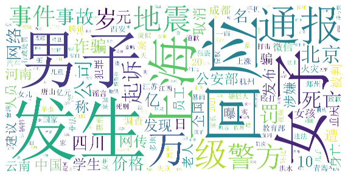

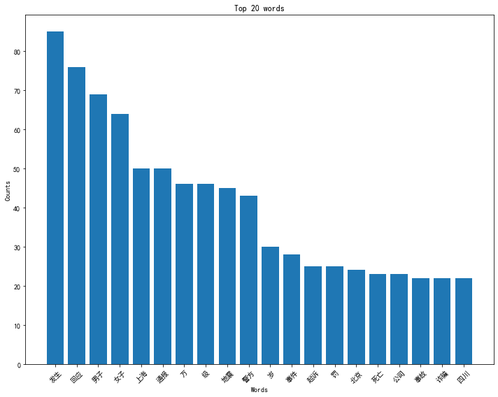

```python
pos_df = process.get_sentiment_data('负向情感')
tt.set_texts(pos_df['事件'].tolist())
tt.get_tokens()
tt.plot_wordcloud()
tt.plot_top_n_words()
```

## 模型训练

```python
train_df, test_df = process.split_data()
feature_col = ['微博数', '点赞', '转发', '评论', '粉丝', '关注', '地域', '情感倾向']
label_col = '热度'
```

```python
model = XgbModel(train_df, feature_col, label_col)
model.train(epochs=10000)
```

## 效果评估

```python
res = model.predict(test_df)
test_df['score'] = res
val = Eval(test_df[label_col], test_df['score'])
```

### 真实值预测值对比

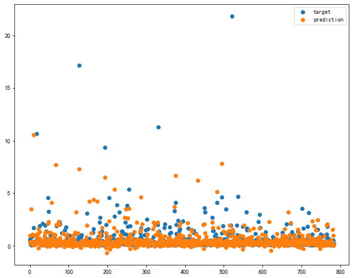

```python
val.plot()
```

### 计算评估指标MAE和MSE

```python
print('MAE: ', val.cal_mae())
print('MSE: ', val.cal_mse())
```

```
MAE:  0.510117693684843
MSE:  1.6496423404137979
```

### 特征重要性

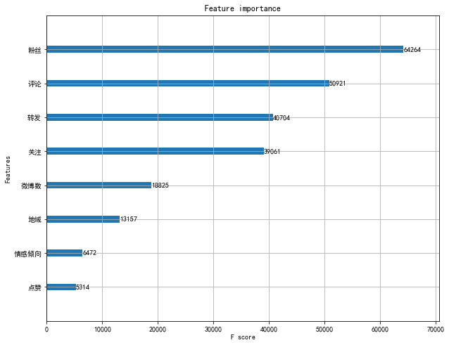

```python
model.plot_importance()
```

## 结论

我们首先对微博原始数据进行清洗和处理，然后对其中的文本进行了情感倾向的分析。

其次，我们对数据集进行划分，分为训练集和测试集，我们在训练集上建立了一种基于xgboost的梯度提升树模型的机器学习算法， 以清洗后数据的话题微博数, 话题总点赞数, 话题总转发数, 话题总评论数, 话题下博主粉丝数, 话题下博主关注数, 话题下博主所属地域数, 话题情感倾向为特征，以话题热度为目标变量进行建模。建立了一个可以预测话题热度，从而发现微博热度话题变化趋势的模型，该模型在测试集上进行评估，MAE为0.51，MSE为1.65，总体效果良好。

同时，我们在建立模型后，不仅可以用于预测话题热度，我们也从模型的特征重要性中得到结论，对话题热度起到主导作用的特征前三名是话题下博主粉丝数、话题总评论数和话题总转发数，这符合我们的主观认知，同时模型和数据也佐证了我们的结论。